# Project 1 - Happy and Unhappy Customers

## Introduction

### Background:

We are one of the fastest growing startups in the logistics and delivery domain. We work with several partners and make on-demand delivery to our customers. From operational standpoint we have been facing several different challenges and everyday we are trying to address these challenges.

We thrive on making our customers happy. As a growing startup, with a global expansion strategy we know that we need to make our customers happy and the only way to do that is to measure how happy each customer is. If we can predict what makes our customers happy or unhappy, we can then take necessary actions.

Getting feedback from customers is not easy either, but we do our best to get constant feedback from our customers. This is a crucial function to improve our operations across all levels.

We recently did a survey to a select customer cohort. You are presented with a subset of this data. We will be using the remaining data as a private test set.

### Data Description:

- Y = target attribute (Y) with values indicating 0 (unhappy) and 1 (happy) customers
- X1 = my order was delivered on time
- X2 = contents of my order was as I expected
- X3 = I ordered everything I wanted to order
- X4 = I paid a good price for my order
- X5 = I am satisfied with my courier
- X6 = the app makes ordering easy for me

Attributes X1 to X6 indicate the responses for each question and have values from 1 to 5 where the smaller number indicates less and the higher number indicates more towards the answer.

### Goal(s):

Predict if a customer is happy or not based on the answers they give to questions asked. Success Metrics:

Reach 73% accuracy score or above, or convince us why your solution is superior. We are definitely interested in every solution and insight you can provide us.

Try to submit your working solution as soon as possible. The sooner the better. Bonus(es):

We are very interested in finding which questions/features are more important when predicting a customer’s happiness. Using a feature selection approach show us understand what is the minimal set of attributes/features that would preserve the most information about the problem while increasing predictability of the data we have. Is there any question that we can remove in our next survey?

## Packages

```python
import os

import pandas as pd  # data, plotting, etc...
import numpy as np
import matplotlib.pyplot as plt
import seaborn as sns
import json
import pandoc

import statsmodels.api as sm  # stats models for analysis
import random  # for setting seed
# from scipy.stats import randint, uniform
# import lazypredict  # ml packages, models, tools, etc..
# from lazypredict.Supervised import LazyClassifier

from sklearn.utils import shuffle
from sklearn.model_selection import train_test_split  # ml transformations
from sklearn.preprocessing import Binarizer
# from sklearn.pipeline import Pipeline
# from sklearn.preprocessing import StandardScaler
# from sklearn.metrics import confusion_matrix
from sklearn.metrics import accuracy_score
# from sklearn.model_selection import GridSearchCV
# from sklearn.model_selection import RandomizedSearchCV
from sklearn.naive_bayes import BernoulliNB  # new models to use
from sklearn.ensemble import ExtraTreesClassifier
from xgboost import XGBClassifier
from sklearn.linear_model import LogisticRegression
# from sklearn.neighbors import KNeighborsClassifier
# from sklearn.linear_model import LogisticRegression

from sklearn.metrics import recall_score  # accuracy score
from sklearn.metrics import confusion_matrix
from sklearn.metrics import classification_report
from sklearn.metrics import matthews_corrcoef

from sklearn.utils.class_weight import compute_class_weight  # weights

from sklearn.ensemble import VotingClassifier  # ensemble techniques
from sklearn.ensemble import StackingClassifier

from sklearn.feature_selection import RFE  # feature selection

from hyperopt import fmin, tpe, hp, STATUS_OK  # hyper parameter tuning
from hyperopt.pyll.base import scope
from hyperopt import space_eval

from watermark import watermark  # watermarking

import warnings
```

## Setup

```python
# Random Seed
# seed = random.randint(1000, 9999)
# print(seed)

# Seeds
seed = 3921
np.random.seed(seed)

seeds_to_run = ['1110', '1314', '1319', '1385', '1654', '2041', '2043', '2229',
                '2495', '2534', '2553', '2743', '2921', '2995', '3128', '3155',
                '3175', '3461', '3560', '3700', '3921', '4198', '4266', '4473',
                '4840', '5106', '5640', '5666', '6019', '6058', '6465', '7143',
                '7191', '7622', '7795', '7828', '8287', '8712', '8758', '8777',
                '8854', '8998', '9085', '9125', '9160', '9198', '9328', '9410',
                '9444', '9829'
                ]

# Show all rows and columns
pd.set_option("display.max_rows", None)  # Show all rows
pd.set_option("display.max_columns", None)  # Show all columns
pd.set_option("display.width", 1000)  # Adjust width for long outputs

# Show all rows and columns
pd.set_option("display.max_rows", None)  # Show all rows
pd.set_option("display.max_columns", None)  # Show all columns
pd.set_option("display.width", 1000)  # Adjust width for long outputs

# Set Directory
path_dir = r'E:\My Stuff\Projects\Apziva\pG736HzU7DLB8fEa'
os.chdir(path_dir)

# data
df = pd.read_csv("ACME-HappinessSurvey2020.csv")
fitted_models = {}

# X, y
X, y = shuffle(df.iloc[:, 1:], df['Y'], random_state=seed)

X_train, X_test, y_train, y_test = train_test_split(X,
                                                    y,
                                                    test_size=0.55,
                                                    random_state=seed
                                                    )

binarizer = Binarizer(threshold=3)  # this is for BernoulliNB model later

X_train_binary = binarizer.fit_transform(X_train)
X_test_binary = binarizer.fit_transform(X_test)

# Assuming y_train contains the labels
class_weights = compute_class_weight(
    class_weight='balanced',
    classes=np.unique(y_train),
    y=y_train
)

class_weight_dict = dict(enumerate(class_weights))
sample_weights = np.array([class_weight_dict[label] for label in y_train])
```

## Description

```python
# Describe; mean, std, etc..
display(df.describe())
```

|  | Y | X1 | X2 | X3 | X4 | X5 | X6 |
| --- | --- | --- | --- | --- | --- | --- | --- |
| count | 126.000000 | 126.000000 | 126.000000 | 126.000000 | 126.000000 | 126.000000 | 126.000000 |
| mean | 0.547619 | 4.333333 | 2.531746 | 3.309524 | 3.746032 | 3.650794 | 4.253968 |
| std | 0.499714 | 0.800000 | 1.114892 | 1.023440 | 0.875776 | 1.147641 | 0.809311 |
| min | 0.000000 | 1.000000 | 1.000000 | 1.000000 | 1.000000 | 1.000000 | 1.000000 |
| 25% | 0.000000 | 4.000000 | 2.000000 | 3.000000 | 3.000000 | 3.000000 | 4.000000 |
| 50% | 1.000000 | 5.000000 | 3.000000 | 3.000000 | 4.000000 | 4.000000 | 4.000000 |
| 75% | 1.000000 | 5.000000 | 3.000000 | 4.000000 | 4.000000 | 4.000000 | 5.000000 |
| max | 1.000000 | 5.000000 | 5.000000 | 5.000000 | 5.000000 | 5.000000 | 5.000000 |

Note mean of Y is a little bit higher than 0.5 at 0.54 indicating a little bit of an unbalanced dataset.

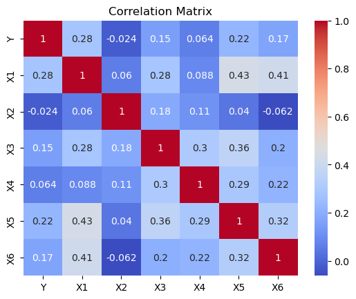

```python
# Correlation
sns.heatmap(df.corr(), annot=True, cmap='coolwarm')
plt.title("Correlation Matrix")
plt.show()
```

Notes regarding the correlation matrix.

- X1 has the strongest positive correlation with Y (0.28).
- X5 and X6 also have moderate correlations.
- X2 and X4 do not seem to impact Y much.
- X3 has a small positive effect but is weakest of the positive effects.

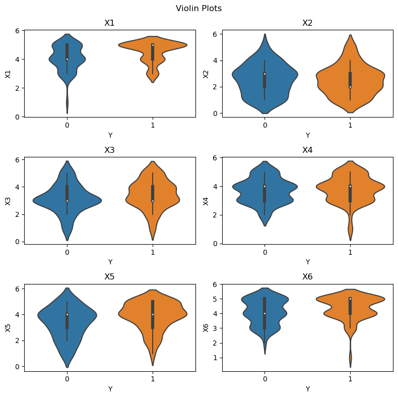

```python
# Violin Plots
fig_violin, axes = plt.subplots(3, 2, figsize=(8, 8))
for i, ax in enumerate(axes.flat):
    sns.violinplot(x=df['Y'], y=df.iloc[:, i+1], ax=ax)
    ax.set_title(f"{df.columns[i+1]}")

fig_violin.suptitle("Violin Plots")
plt.tight_layout()
plt.show()
```

Notes regarding violin plot

- X1 is fairly distinct for both classes and shows concentrated groups at the top for Y=1, and Y=0 is a little more spread out.
- X2 bellows out for both groups, this could indicate some issue with orders not arriving with the expected contents as a typical issue?
- X3 is fairly neutral with both groups concentrated in the middle.
- X4 No extreme polarization, fairly balanced across for both groups
- X5 fairly balanced
- X6 similarly balanced a little more concentrated at the top for Y=1.

Overall, X1 has a fairly distinct pattern between Y0 and Y1 and indicates polarization between groups for that survey question.

## Logistic Regression Results

```python
%%capture

def run_single_regressions(y_df, x_df):
    results = []
    pred = []
    models = []

    for col in x_df.columns:
        X = df[col]
        X = sm.add_constant(X)

        # Fit the regression model
        model = sm.Logit(y_df, X).fit()
        models.append(model)

        # Predict
        pred.append(model.predict(X))

        # Collect the results
        results.append({
            'Variable': col,
            'Coefficient': model.params[1],
            'Intercept': model.params[0],
            'P-Value': model.pvalues[1],
            # 'R-Squared': model.rsquared
        })
    return results, pred, models


# Return results and setup for cm
results, pred, models = run_single_regressions(df['Y'], df[df.columns[1:]])

# Standardizing did nothing to improve accuracy
# results, pred, models = run_single_regressions(
#     df['Y'],
#     scaler.fit_transform(df[df.columns[1:]])
# )
```

```python
results = pd.DataFrame(results)
pred = [[int(y >= 0.5) for y in x] for x in pred]
results['accuracy'] = list(map(lambda x: accuracy_score(df['Y'], x), pred))
results['description'] = ('''X1 = my order was delivered on time
X2 = contents of my order was as I expected
X3 = I ordered everything I wanted to order
X4 = I paid a good price for my order
X5 = I am satisfied with my courier
X6 = the app makes ordering easy for me ''').split('\n')

print('Consolidated Results for Single Logistic Regressions')
display(results)
```

```
Consolidated Results for Single Logistic Regressions
```

|  | Variable | Coefficient | Intercept | P-Value | accuracy | description |
| --- | --- | --- | --- | --- | --- | --- |
| 0 | X1 | 0.757427 | -3.090053 | 0.002473 | 0.650794 | X1 = my order was delivered on time |
| 1 | X2 | -0.043912 | 0.302340 | 0.785305 | 0.547619 | X2 = contents of my order was as I expected |
| 2 | X3 | 0.303085 | -0.808001 | 0.094046 | 0.555556 | X3 = I ordered everything I wanted to order |
| 3 | X4 | 0.148650 | -0.365069 | 0.470644 | 0.555556 | X4 = I paid a good price for my order |
| 4 | X5 | 0.407106 | -1.290577 | 0.013773 | 0.603175 | X5 = I am satisfied with my courier |
| 5 | X6 | 0.426697 | -1.621522 | 0.064193 | 0.611111 | X6 = the app makes ordering easy for me |

Notes regarding logistic regression results

- X1 shows statistical significance at the highest level of 1%. Has the strongest influence with a coef of 0.75.
- X5 shows statistical significance at 5%. Has a moderate influence with a coef of 0.42.
- X3 and X6 show statistical significance at 10%. Also have a moderate influences with a coef of 0.30 and 0.40 respectively.

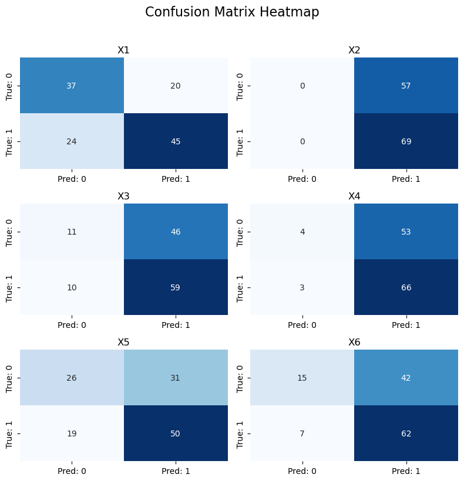

```python
# Plot Confusion Matrix
fig_cm, axes = plt.subplots(3, 2, figsize=(8, 8))

for i, ax in enumerate(axes.flat):
    cm = confusion_matrix(df['Y'], pred[i])
    sns.heatmap(cm, annot=True, fmt='d', cmap='Blues', cbar=False,
                xticklabels=['Pred: 0', 'Pred: 1'],
                yticklabels=['True: 0', 'True: 1'], ax=ax
                )
    ax.set_title(f'{df.columns[i+1]}')

fig_cm.suptitle("Confusion Matrix Heatmap", fontsize=16, y=1.02)
plt.tight_layout()
plt.show()
```

Further evidence for X1, X3, X5, and X6 showing their ability to predict Y to some degree. X1 is the best, with X3, X5, and X6 showing some promise. However, they seem to have a more pure strategy than X1.

X2 and X4 take on more pure strategies and probably don't explain Y very well.

Note that for most predictors, a logistic regression doesn't seem to predict Y very well, indicating that this problem is likely to be non-linear and a more complex model would be needed.

## Aggregate Performance Results

I wanted to analyze which data splits and models perform best, so I used LazyPredict to run multiple models while logging their performance and aggregating accuracy results across 50 seeds.

Looking at the results, I saw that model accuracy and standard deviation tend to have diminishing returns at around a 0.55 split between train and test sets.

Regarding accuracy or the best models, BernoulliNB, ExtraTreesClassifier, and XGBClassifier had good accuracy scores while keeping a low standard deviation across our seeds. These should also be good models for capturing non-linear relationships between y and X.

Table Name and What I Measured:

- mean_by_level: This is the average accuracy for models across all seeds.
- std_by_level: This is the average standard deviation for models across all seeds.
- mean_by_split: This is the average accuracy for splits across all models.
- std_by_split: This is the average standard deviation for splits across all models.

```python
# read log file
with open(".log-lz  (Splits 0.2 to 0.8).json", "r") as log_file:
    lz_log = json.load(log_file)

len(lz_log.keys())

# setup empty dict
measures = ['mean_by_level', 'std_by_level',
            'mean_by_split', 'std_by_split'
            ]

seed_results = {key: [] for key in measures}

#  consolidate each measure by seed -------------------------------------------
for measure in measures:
    for key in lz_log.keys():  # each seed
        json_data = json.loads(lz_log[key][measure])
        seed_results[measure].append(pd.DataFrame(json_data))

for key in seed_results.keys():
    seed_results[key] = pd.concat(seed_results[key], ignore_index=False)
    seed_results[key] = seed_results[key].groupby(level=0).mean()
# -----------------------------------------------------------------------------
```

```python
# Display Aggregated Tables

print('mean_by_level')
sorted_df = seed_results['mean_by_level'].sort_values(by='Accuracy', ascending=False)
display(sorted_df)

print('std_by_level')
sorted_df = seed_results['std_by_level'].sort_values(by='Accuracy', ascending=False)
display(sorted_df)

print('mean_by_split')
display(seed_results['mean_by_split'])

print('std_by_split')
display(seed_results['std_by_split'])
```

```
mean_by_level
```

|  | Accuracy | Balanced Accuracy | ROC AUC | F1 Score |
| --- | --- | --- | --- | --- |
| BernoulliNB | 0.586787 | 0.587790 | 0.587790 | 0.581580 |
| LGBMClassifier | 0.566139 | 0.568933 | 0.568933 | 0.519571 |
| XGBClassifier | 0.565484 | 0.563501 | 0.563501 | 0.561604 |
| RandomForestClassifier | 0.561706 | 0.559116 | 0.559116 | 0.554643 |
| NearestCentroid | 0.560176 | 0.560406 | 0.560406 | 0.558655 |
| ExtraTreesClassifier | 0.556858 | 0.555080 | 0.555080 | 0.551628 |
| BaggingClassifier | 0.556728 | 0.558007 | 0.558007 | 0.553990 |
| RidgeClassifierCV | 0.555219 | 0.553018 | 0.553018 | 0.539762 |
| LogisticRegression | 0.554386 | 0.552696 | 0.552696 | 0.541419 |
| LinearSVC | 0.553006 | 0.550819 | 0.550819 | 0.541153 |
| RidgeClassifier | 0.552335 | 0.549948 | 0.549948 | 0.540005 |
| LinearDiscriminantAnalysis | 0.552277 | 0.549762 | 0.549762 | 0.540232 |
| ExtraTreeClassifier | 0.552163 | 0.551052 | 0.551052 | 0.548551 |
| GaussianNB | 0.549023 | 0.548156 | 0.548156 | 0.541272 |
| LabelPropagation | 0.547090 | 0.544256 | 0.544256 | 0.543053 |
| NuSVC | 0.546043 | 0.544198 | 0.544198 | 0.538347 |
| LabelSpreading | 0.545682 | 0.542664 | 0.542664 | 0.541460 |
| SVC | 0.541845 | 0.542062 | 0.542062 | 0.512795 |
| DecisionTreeClassifier | 0.539641 | 0.537532 | 0.537532 | 0.536853 |
| KNeighborsClassifier | 0.536709 | 0.531416 | 0.531416 | 0.521891 |
| CalibratedClassifierCV | 0.529012 | 0.523274 | 0.523274 | 0.468275 |
| QuadraticDiscriminantAnalysis | 0.526298 | 0.527115 | 0.527115 | 0.519302 |
| AdaBoostClassifier | 0.524246 | 0.525134 | 0.525134 | 0.519809 |
| Perceptron | 0.520671 | 0.520230 | 0.520230 | 0.505908 |
| SGDClassifier | 0.520023 | 0.520885 | 0.520885 | 0.504825 |
| DummyClassifier | 0.513311 | 0.500000 | 0.500000 | 0.350958 |
| PassiveAggressiveClassifier | 0.511727 | 0.509328 | 0.509328 | 0.490150 |

```
std_by_level
```

|  | Accuracy | Balanced Accuracy | ROC AUC | F1 Score |
| --- | --- | --- | --- | --- |
| Perceptron | 0.077743 | 0.075161 | 0.075161 | 0.083741 |
| SGDClassifier | 0.077192 | 0.073841 | 0.073841 | 0.085590 |
| PassiveAggressiveClassifier | 0.075027 | 0.070561 | 0.070561 | 0.084878 |
| LGBMClassifier | 0.064969 | 0.061833 | 0.061833 | 0.123738 |
| BaggingClassifier | 0.057044 | 0.056952 | 0.056952 | 0.058240 |
| ExtraTreeClassifier | 0.056818 | 0.055719 | 0.055719 | 0.057838 |
| DecisionTreeClassifier | 0.055886 | 0.055698 | 0.055698 | 0.056563 |
| DummyClassifier | 0.054066 | 0.000000 | 0.000000 | 0.059945 |
| XGBClassifier | 0.053240 | 0.051464 | 0.051464 | 0.054409 |
| AdaBoostClassifier | 0.052211 | 0.052100 | 0.052100 | 0.053291 |
| CalibratedClassifierCV | 0.052063 | 0.044287 | 0.044287 | 0.080926 |
| QuadraticDiscriminantAnalysis | 0.050556 | 0.050405 | 0.050405 | 0.053617 |
| RandomForestClassifier | 0.049314 | 0.048027 | 0.048027 | 0.051325 |
| KNeighborsClassifier | 0.047806 | 0.046662 | 0.046662 | 0.052206 |
| NuSVC | 0.047542 | 0.046953 | 0.046953 | 0.050291 |
| BernoulliNB | 0.047285 | 0.045959 | 0.045959 | 0.051436 |
| SVC | 0.046648 | 0.043661 | 0.043661 | 0.059737 |
| LabelPropagation | 0.045145 | 0.044927 | 0.044927 | 0.046247 |
| GaussianNB | 0.044750 | 0.044971 | 0.044971 | 0.047574 |
| NearestCentroid | 0.044583 | 0.045221 | 0.045221 | 0.045551 |
| LabelSpreading | 0.044339 | 0.044112 | 0.044112 | 0.045471 |
| ExtraTreesClassifier | 0.044301 | 0.042650 | 0.042650 | 0.045405 |
| LinearDiscriminantAnalysis | 0.043805 | 0.042172 | 0.042172 | 0.047735 |
| RidgeClassifierCV | 0.043550 | 0.041739 | 0.041739 | 0.050059 |
| RidgeClassifier | 0.043512 | 0.041667 | 0.041667 | 0.047914 |
| LogisticRegression | 0.043024 | 0.041325 | 0.041325 | 0.048032 |
| LinearSVC | 0.042614 | 0.040886 | 0.040886 | 0.046882 |

```
mean_by_split
```

|  | Accuracy | Balanced Accuracy | ROC AUC | F1 Score |
| --- | --- | --- | --- | --- |
| 0.2 | 0.550513 | 0.549553 | 0.549553 | 0.536411 |
| 0.25 | 0.558148 | 0.556173 | 0.556173 | 0.544253 |
| 0.3 | 0.551637 | 0.549806 | 0.549806 | 0.536547 |
| 0.35 | 0.549152 | 0.547036 | 0.547036 | 0.533383 |
| 0.4 | 0.548584 | 0.546725 | 0.546725 | 0.532178 |
| 0.45 | 0.546940 | 0.544899 | 0.544899 | 0.531104 |
| 0.5 | 0.550935 | 0.547715 | 0.547715 | 0.534693 |
| 0.55 | 0.546624 | 0.544100 | 0.544100 | 0.529495 |
| 0.6 | 0.546355 | 0.543626 | 0.543626 | 0.529217 |
| 0.65 | 0.542620 | 0.539969 | 0.539969 | 0.522724 |
| 0.7 | 0.537054 | 0.535221 | 0.535221 | 0.512492 |
| 0.75 | 0.533287 | 0.532669 | 0.532669 | 0.508203 |
| 0.8 | 0.527767 | 0.528914 | 0.528914 | 0.499670 |

```
std_by_split
```

|  | Accuracy | Balanced Accuracy | ROC AUC | F1 Score |
| --- | --- | --- | --- | --- |
| 0.2 | 0.077238 | 0.076948 | 0.076948 | 0.088222 |
| 0.25 | 0.069437 | 0.068920 | 0.068920 | 0.082440 |
| 0.3 | 0.064158 | 0.063208 | 0.063208 | 0.077918 |
| 0.35 | 0.055331 | 0.055219 | 0.055219 | 0.069820 |
| 0.4 | 0.055446 | 0.054600 | 0.054600 | 0.071532 |
| 0.45 | 0.053055 | 0.052821 | 0.052821 | 0.069154 |
| 0.5 | 0.049467 | 0.049317 | 0.049317 | 0.066402 |
| 0.55 | 0.047402 | 0.046575 | 0.046575 | 0.066476 |
| 0.6 | 0.049865 | 0.047780 | 0.047780 | 0.068994 |
| 0.65 | 0.048946 | 0.047763 | 0.047763 | 0.069379 |
| 0.7 | 0.048506 | 0.046058 | 0.046058 | 0.075439 |
| 0.75 | 0.046029 | 0.043070 | 0.043070 | 0.073499 |
| 0.8 | 0.046848 | 0.044635 | 0.044635 | 0.075046 |

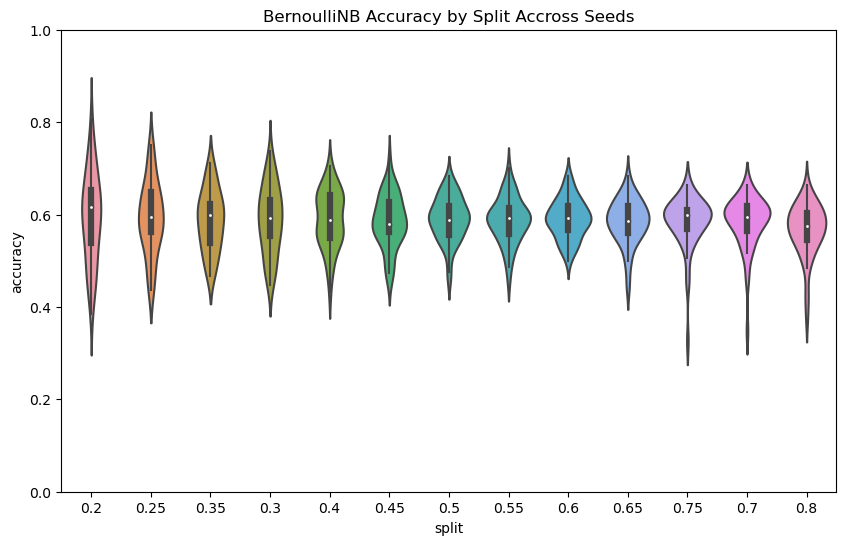

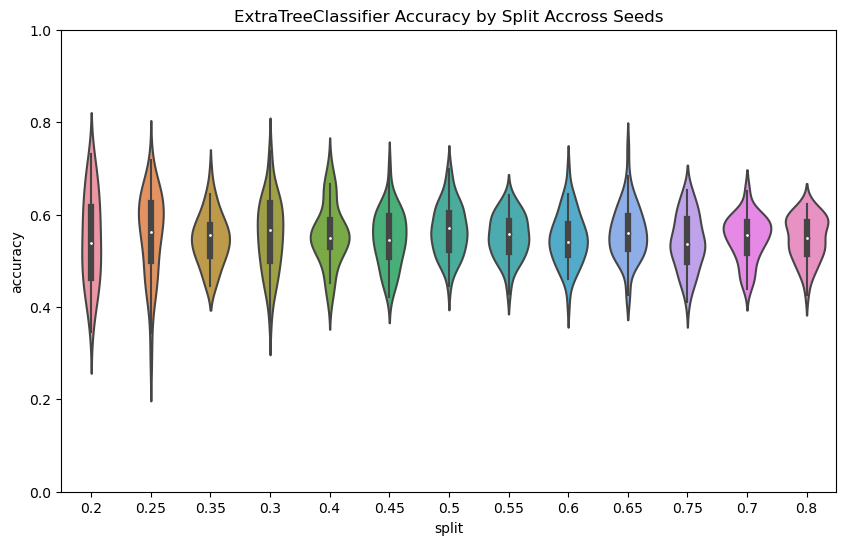

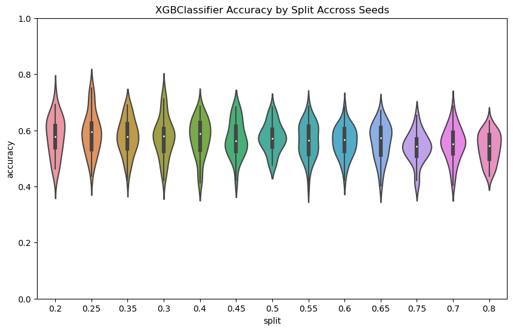

```python
warnings.simplefilter("ignore")

# Graph Model Performance Accross Splits Accross Seeds ------------------------
model = 'RandomForestClassifier'

model_list = [
    'BernoulliNB',
    'ExtraTreeClassifier',
    'XGBClassifier'
    ]


for model in model_list:
    df_performance = pd.DataFrame(columns=['split', 'accuracy'])
    for key in seeds_to_run:
        for split, value in lz_log[key]['.data_by_split'].items():
            get_accuracy = {
                'split': split,
                'accuracy': json.loads(value)[model]['Accuracy']
                }
            get_accuracy = pd.Series(get_accuracy)

            df_performance = df_performance.append(
                get_accuracy,
                ignore_index=True
                )

    plt.figure(figsize=(10, 6))

    sns.violinplot(
        x=df_performance['split'],
        y=df_performance['accuracy']
        )

    # Fix the y-axis scale to be between 0 and 1
    plt.ylim(0, 1)

    plt.title(f'{model} Accuracy by Split Accross Seeds')
    plt.show()
# -----------------------------------------------------------------------------
```

These are violin plots aggregating accuracy scores for specific models accross splits from 0.2 to 0.8. Typcially for each of these plots, we can see that around the 0.5 to 0.6 split range, model accuracy tends to be fairly consistent accross seeds. Anywhere within this range seems most reasonable to tune our models, so I ended up choosing 0.55 to be the split.

## Run Models

Just tried to keep models simple and low complexity. To prevent over fitting, the confusion matrices are checked to make sure models are using balanced strategies. The current parameters are from after using gridsearch to optimize.

I also added in voting models to see if strategies are diverse or unique enough to improve results.

```python
'''
# Models to Run
- bernoulli
- extratress
- xgb
- voting
- stacking
'''

# BernoulliNB -----------------------------------------------------------------
model = BernoulliNB(
    alpha=0.5,
    force_alpha=False,
    binarize=3,
    fit_prior=True,
    class_prior=[0.55, 0.45]
    )
# model = model.fit(X_train, y_train)
model = model.fit(X_train, y_train, sample_weight=sample_weights)
fitted_models['BernoulliNB'] = model
# -----------------------------------------------------------------------------

# ExtraTreesClassifier --------------------------------------------------------
model = ExtraTreesClassifier(
    n_estimators=100,
    max_depth=2,
    min_samples_split=3,
    min_samples_leaf=1,
    bootstrap=False,
    random_state=seed,
    class_weight={0: 1.025, 1: 0.975}
    )
# model = model.fit(X_train, y_train)
model = model.fit(X_train, y_train, sample_weight=sample_weights)
fitted_models['ExtraTreesClassifier'] = model
# -----------------------------------------------------------------------------

# XGBClassifier ---------------------------------------------------------------
model = XGBClassifier(
    n_estimators=50,
    learning_rate=0.030,
    max_depth=3,
    min_child_weight=3,
    subsample=0.8,
    colsample_bytree=0.9,
    random_state=seed,
)

# model = model.fit(X_train, y_train)

model = model.fit(X_train, y_train, sample_weight=sample_weights)
fitted_models['XGBClassifier'] = model
# -----------------------------------------------------------------------------

# Copy Models for Ensemble ----------------------------------------------------
voting_models = fitted_models.copy()
voting_models = list(voting_models.items())
# -----------------------------------------------------------------------------

# Voting ----------------------------------------------------------------------
model = VotingClassifier(
    estimators=voting_models,
    voting='soft',
    )

# model = model.fit(X_train, y_train)

model = model.fit(X_train, y_train, sample_weight=sample_weights)
fitted_models['Voting'] = model
# -----------------------------------------------------------------------------

# Stacking --------------------------------------------------------------------
meta_model = LogisticRegression()

model = StackingClassifier(
    estimators=voting_models, final_estimator=meta_model)

# model = model.fit(X_train, y_train)

model = model.fit(X_train, y_train, sample_weight=sample_weights)
fitted_models['Stacking'] = model
# -----------------------------------------------------------------------------
```

## Model Performance Results

For the accuracy scoring, I used 'recall for 0', and forced a balanced training dataset between classes 0 and 1 to make sure models didn't prioritize class 1 over 0. I made the swap to 'recall for 0' because having a focus on unhappy customers might give us some insights on where the business is struggling to maintain customer satisfaction.

I used two benchmarks, a naive strategy, and a random strategy, to create a baseline for our models to compare against. There is a greater focus to beat the random strategy rather than the naive. The naive model essentially shows an over fitting model.

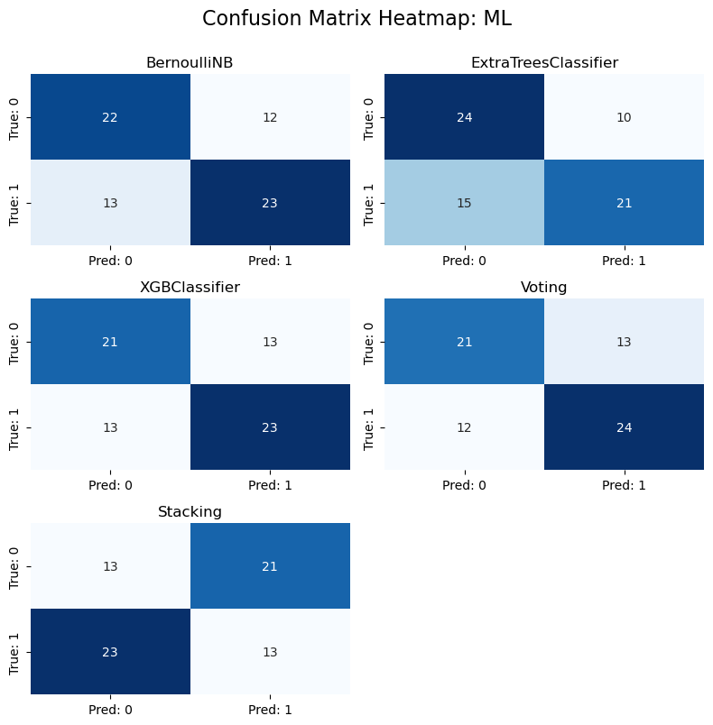

```python
# Functions & Results ---------------------------------------------------------
'''
- recall score
- confusion
- classification report
'''


def get_recall_score(x):
    model = fitted_models[x]

    y_pred = model.predict(X_test)

    result = recall_score(y_test, y_pred, pos_label=0)
    return x, result


def get_confusion_matricies(x):
    try:
        model = fitted_models[x]

        y_pred = model.predict(X_test)

        result = confusion_matrix(y_test, y_pred)
        return x, result
    except Exception:
        return x, None


def get_classification_report(x):
    model = fitted_models[x]

    y_pred = model.predict(X_test)

    result = classification_report(y_test, y_pred)
    return x, result


recall_results = dict(map(get_recall_score, fitted_models))

confusion_matricies = dict(map(get_confusion_matricies, fitted_models))

classification_report_results = dict(
    map(get_classification_report, fitted_models))
# -----------------------------------------------------------------------------

# Benchmarks ------------------------------------------------------------------
'''
- naive
- mean
'''


def calculate_random_predictions(y_train, y_test):
    unique, counts = np.unique(y_train, return_counts=True)
    class_probs = counts / len(y_train)  # Probabilities for y=0 and y=1
    random_y = np.random.choice(unique, size=len(y_test), p=class_probs)
    return random_y


# based on train class distributions - keeps being random each time I run?
baseline_random = recall_score(
    y_test,
    calculate_random_predictions(y_train, y_test),
    pos_label=0
    )

baseline_mean = recall_score(
    y_test,
    [0] * len(y_test),
    pos_label=0
    )
# -----------------------------------------------------------------------------

# Confusion Plots -------------------------------------------------------------
fig_cm2, axes = plt.subplots(3, 2, figsize=(8, 8))

for i, ax in enumerate(axes.flat):
    try:
        cm = confusion_matricies[list(confusion_matricies.keys())[i]]

        sns.heatmap(cm, annot=True, fmt='d', cmap='Blues', cbar=False,
                    xticklabels=['Pred: 0', 'Pred: 1'],
                    yticklabels=['True: 0', 'True: 1'],
                    ax=ax
                    )
        ax.set_title(f'{list(confusion_matricies.keys())[i]}')
    except Exception:
        ax.axis('off')

fig_cm2.suptitle("Confusion Matrix Heatmap: ML", fontsize=16, y=1.00)
plt.tight_layout()
plt.show()
# -----------------------------------------------------------------------------
```

Confusion plots show a fairly balanced strategy is being used across our three models.

The voting approaches didn't show any considerable gains in combining models. This means models are likely using similar strategies for it's classification.

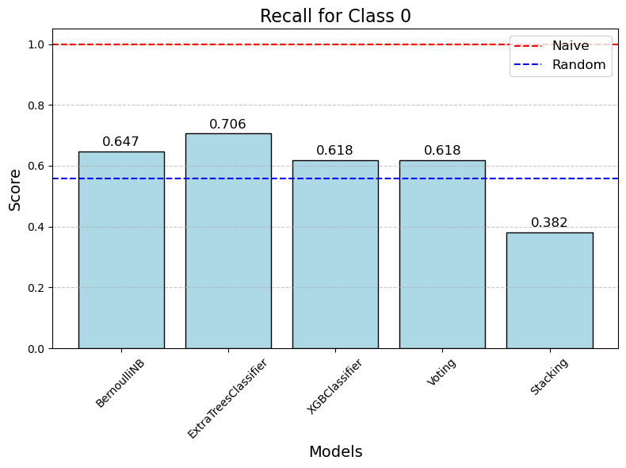

```python
# Bar Plot for Accuracy -------------------------------------------------------
plt.figure(figsize=(8, 6))  # Set the figure size
bars = plt.bar(
        recall_results.keys(),
        recall_results.values(),
        color='lightblue',
        edgecolor='black'
        )

# titles
plt.title('Recall for Class 0', fontsize=16)
plt.xlabel('Models', fontsize=14)
plt.ylabel('Score', fontsize=14)

# grid lines
plt.grid(axis='y', linestyle='--', alpha=0.7)

# benchmarks
plt.axhline(y=baseline_mean, color='red',
            linestyle='--', linewidth=1.5, label='Naive')

plt.axhline(y=baseline_random, color='blue',
            linestyle='--', linewidth=1.5, label='Random')

for bar in bars:
    yval = bar.get_height()
    plt.text(bar.get_x() + bar.get_width() / 2, yval + 0.01,
             f'{yval:.3f}', ha='center', va='bottom', fontsize=12)

# rotate axis on x
plt.xticks(rotation=45)

# legend
plt.legend(loc='upper right', fontsize=12)

plt.tight_layout()
plt.show()
# -----------------------------------------------------------------------------
```

Bar plot shows that we are able to beat a random approach by a decent margin, meaning models are able to capture some relationship between y and X and differentiate between classes.

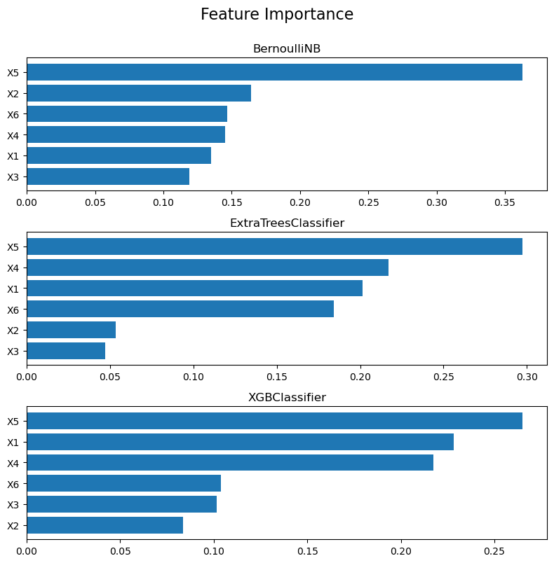

```python
# Feature Importance ----------------------------------------------------------
importance = {}

_nb_model = fitted_models['BernoulliNB']
importance['BernoulliNB'] = np.abs(
    _nb_model.feature_log_prob_[1] - _nb_model.feature_log_prob_[0])

importance['ExtraTreesClassifier'] = fitted_models[
    'ExtraTreesClassifier'].feature_importances_

importance['XGBClassifier'] = fitted_models[
    'XGBClassifier'].feature_importances_

# bar plot
fig_bar, axes = plt.subplots(3, 1, figsize=(8, 8))

_feature_names = list(df.columns)[1:]

for i, ax in enumerate(axes.flat):
    model_name = list(importance.keys())[i]
    sorted_idx = np.argsort(importance[model_name])

    _sorted_feature_names = [_feature_names[i] for i in sorted_idx]
    ax.barh(_sorted_feature_names, importance[model_name][sorted_idx])
    ax.set_title(f'{model_name}')

fig_bar.suptitle("Feature Importance", fontsize=16, y=1.00)
plt.tight_layout()
plt.show()
# -----------------------------------------------------------------------------
```

Previously, X1, X3, X5, and X6 seemed like good predictors for y. However, this was without rebalancing the classes, so data was a little more focused on y=1.

These plots show evidence that some variable, one independent of predicting class 1, are good predictors of class 0 which were X1, X4, and X5.

Note that the strongest predictors for class 1 and 0 are a little different this time, which makes sense. For instance, the greatest predictor for happy customers was x1, 'my order was delivered on time', where as for class 0, x5 was the strongest precitor, 'I am satisfied with my courier'. Maybe in these cases, having packages come in on time or early makes customers happy, but delays don't necessarily make them unhappy. On the other hand, while customers may not interact with their couriers often, a negative experience could have a significant impact on their satisfaction.

Overall, ExtraTreeClassifer was able to capture the most True Negatives while having a fairly balance confusion matrix and still have the highest recall for 0 score. We'll be using this model going forward for fine tuning.

## HyperOpt

To further fine tune our selected model, we'll use an objective function and a new scoring method to improve our model. A new scoring method is needed since optimizing for recall for 0 would likely result in over fitting.

The new scoring method I used is the 'Matthews correlation coefficient', which returns a more balanced score. This should make sure that models are not over fitting when tuning.

Three different models using ExtraTreesClassifier were made for:

- no feature reduction and just further tuning our prior model.
- manually picking the best features as decided from our prior results for feature importance.
- using recursive feature elimination to reduce to 3 of our best predictors and then tuning the model.

```python
%%capture

# =============================================================================
# Apply HyperOpt
# =============================================================================

# variables

final_scores = {}

# Create Hyperopt Class


class HyperOptClassifier:
    def __init__(
            self, X_train, X_test, y_train, y_test, sample_weights):

        self.space = space
        self.X_train = X_train
        self.X_test = X_test
        self.y_train = y_train
        self.y_test = y_test
        self.sample_weights = sample_weights

    def objective(self, params):
        model = ExtraTreesClassifier(**params)

        model = model.fit(
            self.X_train,
            self.y_train,
            sample_weight=self.sample_weights
            )

        y_pred = model.predict(self.X_test)

        # confusion matrix
        tn, fp, fn, tp = confusion_matrix(y_test, y_pred).ravel()

        # TNR
        # score = tn / (tn + fp)  # TNR (overfits...)
        # score = tn / (tn + fn)  # NPV
        score = matthews_corrcoef(y_test, y_pred)  # mcc

        # return negative of the score
        return {'loss': -score, 'status': STATUS_OK}

    def run_optimization(self, space, evals=50):
        best = fmin(
            fn=self.objective,
            space=self.space,
            algo=tpe.suggest,
            max_evals=evals
            )

        print("Best hyperparameters:", best)

        return space_eval(self.space, best)


# Define the hyperparameter search space
space = {
    'n_estimators':  scope.int(hp.quniform('n_estimators', 10, 200, 10)),
    'max_depth': scope.int(hp.quniform('max_depth', 1, 15, 1)),
    'min_samples_split': scope.int(hp.quniform('min_samples_split', 2, 15, 1)),
    'min_samples_leaf': scope.int(hp.quniform('min_samples_leaf', 1, 15, 1)),

    'min_weight_fraction_leaf': hp.uniform(
        'min_weight_fraction_leaf', 0.0, 0.5),

    'max_leaf_nodes': scope.int(hp.quniform(
        'max_leaf_nodes', 2, 15, 1)),

    'max_features': hp.choice('max_features', ['sqrt', 'log2', None]),
    'min_impurity_decrease': hp.uniform('min_impurity_decrease', 0.0, 0.2),
    'ccp_alpha': hp.uniform('ccp_alpha', 0.0, 0.1),
    'max_samples': scope.int(hp.quniform('max_samples', 1, 55, 1)),
    'random_state': seed,  # Fixed Parameters...
    'bootstrap': True,
    'n_jobs': -1,
    'class_weight': {0: 1.025, 1: 0.975}
    }

# Hyperopt:ExtraTreesClassifier -----------------------------------------------
hpyer_opt1 = HyperOptClassifier(  # set new object
    X_train,
    X_test,
    y_train,
    y_test,
    sample_weights
    )
best = hpyer_opt1.run_optimization(space)

# create model and fit
model = ExtraTreesClassifier(
    **best,
    )
model = model.fit(X_train, y_train, sample_weight=sample_weights)

# return results
y_pred = model.predict(X_test)

final_scores['Hyperopt:ExtraTreesClassifier'] = recall_score(
    y_test,
    pd.Series(y_pred),
    pos_label=0
    )

fitted_models['HyperOpt:ExtraTreesClassifier'] = model
# -----------------------------------------------------------------------------

# Hyperopt:ExtraTreesClassifier:LessFeatures ----------------------------------
hpyer_opt2 = HyperOptClassifier(  # set new object, less features
    X_train[['X5', 'X4', 'X1']],
    X_test[['X5', 'X4', 'X1']],
    y_train,
    y_test,
    sample_weights
    )

best = hpyer_opt2.run_optimization(space)

# create model and fit
model = ExtraTreesClassifier(
    **best,
    )

model = model.fit(
    X_train[['X5', 'X4', 'X1']], y_train, sample_weight=sample_weights
    )

# return results
y_pred = model.predict(X_test[['X5', 'X4', 'X1']])

final_scores['Hyperopt:ExtraTreesClassifier:LessFeatures'] = recall_score(
    y_test,
    pd.Series(y_pred),
    pos_label=0
    )

fitted_models['HyperOpt:ExtraTreesClassifier:LessFeatures'] = model
# -----------------------------------------------------------------------------

# HyperOpt:ExtraTreesClassifier:RFE -------------------------------------------
rfe = RFE(estimator=ExtraTreesClassifier(
    random_state=seed,
    class_weight={0: 1.025, 1: 0.975},
    n_jobs=-1),
    n_features_to_select=3
    )

rfe.fit(X_train, y_train)
for i in range(X_train.shape[1]):
    print(
        f"Column: {X_train.columns[i]}, "
        f"Selected: {rfe.support_[i]}, "
        f"Rank: {rfe.ranking_[i]:.3f}"
    )

hpyer_opt3 = HyperOptClassifier(  # set new object, less features
    X_train[['X5', 'X3', 'X2']],
    X_test[['X5', 'X3', 'X2']],
    y_train,
    y_test,
    sample_weights
    )

best = hpyer_opt3.run_optimization(space)

# create model and fit
model = ExtraTreesClassifier(
    **best,
    )

model = model.fit(
    X_train[['X5', 'X3', 'X2']], y_train, sample_weight=sample_weights
    )

# return results
y_pred = model.predict(X_test[['X5', 'X3', 'X2']])

final_scores['Hyperopt:ExtraTreesClassifier:RFE'] = recall_score(
    y_test,
    pd.Series(y_pred),
    pos_label=0
    )

fitted_models['HyperOpt:ExtraTreesClassifier:RFE'] = model
# -----------------------------------------------------------------------------
```

[figure not shown]

```python
# =============================================================================
# Graph the Results
# =============================================================================

confusion_matricies = dict(map(get_confusion_matricies, fitted_models))

# manual addition of less features model for ETC.
model = fitted_models['HyperOpt:ExtraTreesClassifier:LessFeatures']

y_pred = model.predict(X_test[['X5', 'X4', 'X1']])
result = confusion_matrix(y_test, y_pred)
confusion_matricies['HyperOpt:ExtraTreesClassifier:LessFeatures'] = result

model = fitted_models['HyperOpt:ExtraTreesClassifier:RFE']

y_pred = model.predict(X_test[['X5', 'X3', 'X2']])
result = confusion_matrix(y_test, y_pred)
confusion_matricies['HyperOpt:ExtraTreesClassifier:RFE'] = result

# Confusion Matricies ---------------------------------------------------------
# Set up the figure and axes
fig_cm2, axes = plt.subplots(2, 2, figsize=(8, 8))
# List of model names and corresponding axes
models = [
    'ExtraTreesClassifier',
    'HyperOpt:ExtraTreesClassifier',
    'HyperOpt:ExtraTreesClassifier:LessFeatures',
    'HyperOpt:ExtraTreesClassifier:RFE'
]

titles = [
    'ExtraTreesClassifier',
    'HyperOpt:ExtraTreesClassifier',
    'HyperOpt:ExtraTreesClassifier:LessFeatures',
    'HyperOpt:ExtraTreesClassifier:RFE'
]

# Loop through axes, models, and titles using enumerate with zip
for i, (ax, model, title) in enumerate(zip(axes.flat, models, titles)):
    sns.heatmap(confusion_matricies[model], annot=True, fmt='d', cmap='Blues',
                cbar=False, xticklabels=['Pred: 0', 'Pred: 1'],
                yticklabels=['True: 0', 'True: 1'], ax=ax)
    ax.set_title(title)

# Adjust layout and show the figure
fig_cm2.suptitle("ExtraTreesClassifier Models", fontsize=16, y=1.00)
plt.tight_layout()
plt.show()
# -----------------------------------------------------------------------------
```

[figure not shown]

```python
# Bar Chart -------------------------------------------------------------------
final_scores['ExtraTreesClassifier'] = recall_results['ExtraTreesClassifier']

plt.figure(figsize=(8, 8))  # Set the figure size
bars = plt.bar(
        final_scores.keys(),
        final_scores.values(),
        color='lightblue',
        edgecolor='black'
        )

# titles
plt.title('Recall for Class 0', fontsize=16)
plt.xlabel('Models', fontsize=14)
plt.ylabel('Score', fontsize=14)

# grid lines
plt.grid(axis='y', linestyle='--', alpha=0.7)

# benchmarks
plt.axhline(y=baseline_mean, color='red',
            linestyle='--', linewidth=1.5, label='Naive')

plt.axhline(y=baseline_random, color='blue',
            linestyle='--', linewidth=1.5, label='Random')

for bar in bars:
    yval = bar.get_height()
    plt.text(bar.get_x() + bar.get_width() / 2, yval + 0.01,
             f'{yval:.3f}', ha='center', va='bottom', fontsize=12)

# rotate axis on x
plt.xticks(rotation=45)

# legend
plt.legend(loc='upper right', fontsize=12)

plt.tight_layout()
plt.show()
# -----------------------------------------------------------------------------
```

By further tuning our models using hyper opt we can improve our model accuracy while also making sure not to over fit. However, our models do become quite a bit more complicated.

There's also no improvement in our models when reducing the dimension of our features.

## Conclusions

### Regarding the Goals of the Project

#### Reach 73% accuracy score or above, or convince us why your solution is superior. We are definitely interested in every solution and insight you can provide us.

However, I recommend focusing on unhappy customers, as this would have a greater business impact by providing insights to improve customer satisfaction rather than finding what is currently working. For instance, the most important feature to indentifying unhappy customers was the survey question, 'I am satisfied with my courier'. This suggests there may be opportunities to provide better training to ensure more positive customer experiences.

#### *We are very interested in finding which questions/features are more important when predicting a customer’s happiness.*

When predicting a customer's happiness, specifically Y=1, predictors such as X1 would be the best, with X3, X5, and X6 showing some promise. On the otherside, predictors such as X1, X4, and X5 were fairly important features for Y=0.

#### *Using a feature selection approach show us understand what is the minimal set of attributes/features that would preserve the most information about the problem while increasing predictability of the data we have.*

You could reduce the feature set down to 3 predictors and still see similar results, but I wouldn't recommend removing any predictors at this stage and just use all predictors for model prediction. This is due to the relatively low number of data points and the nature of the problem being fairly non-linear. Also, reducing the number of features for our models tended to make them approach a more naive strategy, so models will probably be more general with more predictors at this stage.

#### *Is there any question that we can remove in our next survey?*

The questions are fairly good, but I would recommend tuning these questions to better capture both existing happy and unhappy customers better. This is because for some of the questions, respondents who would reply negatively would not be customers in the first place.

For instance, the question, 'I ordered everything I wanted to order', wouldn't capture customers that would say 'no' or give a low score because they wouldn't have made an order in the first place. Looking at the very first violin chart for X3, you can see that both happy and unhappy customers tended to give a neutral 3 score, which tells me that they are probably didn't give the question much thought since it didn't really apply to them. All customers in this dataset would have ordered what they wanted to order, otherwise they wouldn't have ordered in the first place or be a customer.

The same can be said for the question, 'I paid a good price for my order'. Customers that have paid for a delivery have already essentially said that they 'paid a good price for my order', if it wasn't a good price they wouldn't have ordered in the first place.

Overall, rephrasing some of these questions would be a good idea to capture more polarizing groups between happy and unhappy customers while making sure all respondent can possibly answer both positively and negatively to their experiences.

```python
print(watermark())
```

```
Last updated: 2025-02-21T12:25:36.631555-05:00

Python implementation: CPython
Python version       : 3.9.16
IPython version      : 7.31.1

Compiler    : MSC v.1916 64 bit (AMD64)
OS          : Windows
Release     : 10
Machine     : AMD64
Processor   : AMD64 Family 21 Model 2 Stepping 0, AuthenticAMD
CPU cores   : 8
Architecture: 64bit
```